# TCR and CO2 concentration in AR6 and CMIP6

Doug McNeall

2023-01-06

We fit distributions to assessed quantiles of TCR in the literature, and then push those through the transfer function from Betts & McNeall (2018) to find an implied CO2 concentrayion at warming levels 1.5 and 2 degrees above preindustrial.

# Quantiles from the literature

There are a number of sources of assessed probability distributions for TCR (sometimes just quantiles) in the literature. A complicating factor is that they often give a small number of different quantiles, or probability ranges, leaving a large number of potential distributions that would fit. For example, they might state a 66% probability range, without specifying the quantiles this range aplies to.

### AR5 (assessed range)

“likley” range (66% probability)

1 - 2.5 deg C

Also “positive” and “extremely unlikely” (5% probability) above 3"

I interpret this as

| quantile | 0% | 17% | 83% | 97.5% |
| --- | --- | --- | --- | --- |
| tcr | 0 | 1 | 2.5 | 3 |

But it’s possible to interpret that upper quantile as 95%, as there is ambiguity around whether the 5% probability should be split over both tails of the distribution. . I’ll update this possible inconsistancy as I find out.

### CMIP5 models

AR5 Box 12.2 states:

“5 to 95% range of CMIP5 (1.2°C to 2.4°C; see Table 9.5), is positive and extremely unlikely greater than 3°C.” As this explicitly mentions the 95% *and* the “extremely unlikely” statement, that lends evidence that “extremely unlikely” is spread over both tails, and refers to the 97.5th percentile.

[output not shown]

### Schurer eta al (2018)

Multimodel mean with increased variance for model uncertainty

| quantile | 5% | 50% | 95% |
| --- | --- | --- | --- |
| tcr | 1.2 | 1.7 | 2.4 |

### Sherwood et al (2020)

Likely (66% probability) range

| quantile | 16% | 50% | 84% |
| --- | --- | --- | --- |
| tcr | 1.5 | 1.8 | 2.2 |

### Jiménez-de-la Cuesta and Mauritsen (2019)

| quantile | 5% | 50% | 95% |
| --- | --- | --- | --- |
| tcr | 1.17 | 1.7 | 2.16 |

### Tokarska et al (2020)

| quantile | 16% | 50% | 84% |
| --- | --- | --- | --- |
| tcr | 1.2 | 1.6 | 2.0 |

### Njisse et al. (2020)

Njisse et al. (2020) CMIP5 models

| quantile | 5% | 16% | 50% | 84% | 95% |
| --- | --- | --- | --- | --- | --- |
| tcr | 1.1 | 1.4 | 1.7 | 2.1 | 2.4 |

Njisse et al. (2020) CMIP6 models

| quantile | 5% | 16% | 50% | 84% | 95% |
| --- | --- | --- | --- | --- | --- |
| tcr | 1 | 1.29 | 1.68 | 2.05 | 2.3 |

## Distributions used in Betts & McNeall (2018)

```
## [1] 1.302494 2.197506
```

```
## [1] 1.004157 2.495843
```

## Other distributions to might fit TCR better

The distribution from Richardson is asymmetric, and there is evidence that the other distributions representing scientists beliefs are asymmetric too. Normal distributions can easily place significant probability below zero, which is explicitly ruled out in the AR5 assessment.

Other distributions, such as Gamma or lognormal, might fit better.

For example, here is a Gamma distribution with some sensible-looking parameters.

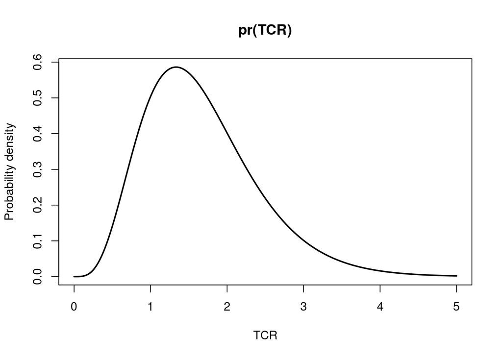

## Fit distributions to the Richardson samples from their TCR distribution

Fit the Gamma distribution, starting from the above parameters.

### Fit a lognormal distribution to Richardson

This seems to fit a little better than the Gamma distribution.

## Fit a lognormal distribution to all of the distributions from the literature

```
## The fitting procedure 'L-BFGS-B' was successful!
```

```
## $par
## [1] 0.4370346 0.4324224
##
## $value
## [1] 0.0002381779
##
## $counts
## function gradient
##       13       13
##
## $convergence
## [1] 0
##
## $message
## [1] "CONVERGENCE: REL_REDUCTION_OF_F <= FACTR*EPSMCH"
```

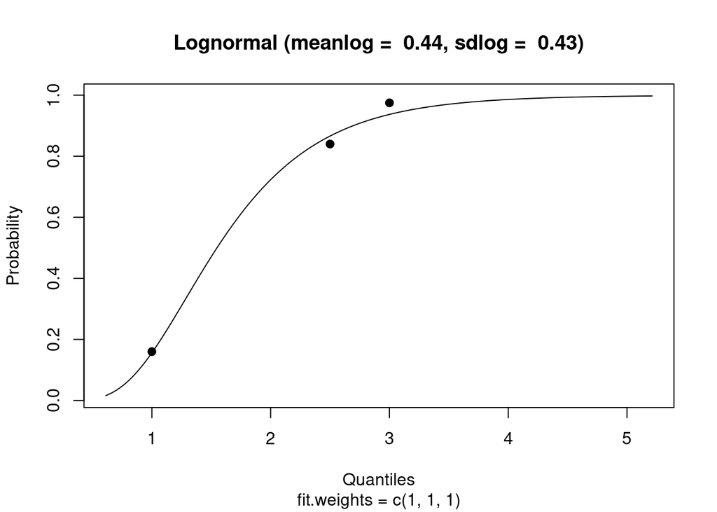

```
## The fitting procedure 'L-BFGS-B' was successful!
```

```
## $par
## [1] 0.5528290 0.2264219
##
## $value
## [1] 3.430531e-05
##
## $counts
## function gradient
##        9        9
##
## $convergence
## [1] 0
##
## $message
## [1] "CONVERGENCE: REL_REDUCTION_OF_F <= FACTR*EPSMCH"
```

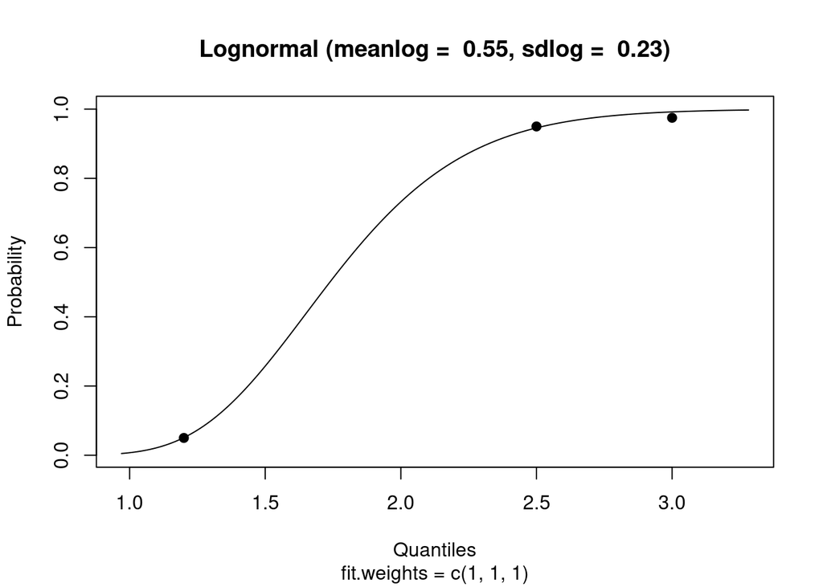

```
## The fitting procedure 'L-BFGS-B' was successful!
```

```
## $par
## [1] 0.5304240 0.2106881
##
## $value
## [1] 1.41057e-07
##
## $counts
## function gradient
##       12       12
##
## $convergence
## [1] 0
##
## $message
## [1] "CONVERGENCE: REL_REDUCTION_OF_F <= FACTR*EPSMCH"
```

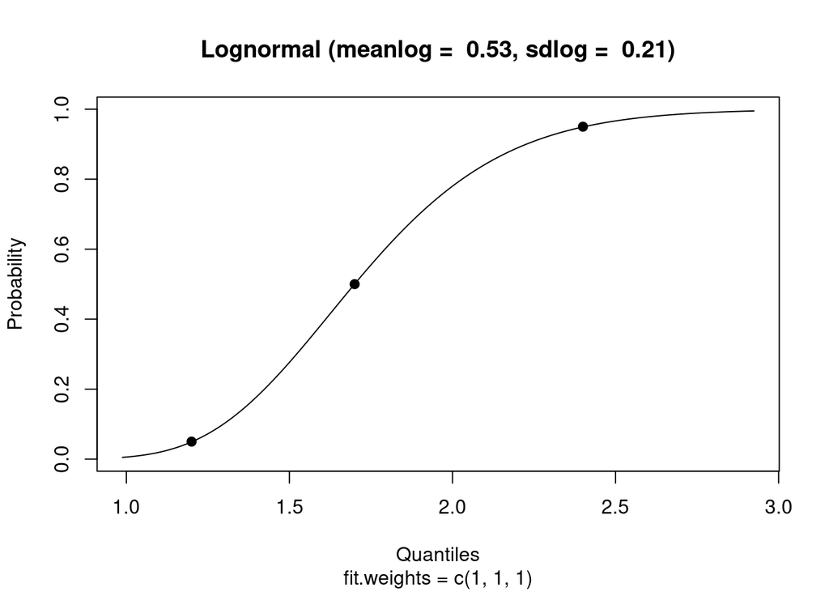

```
## The fitting procedure 'L-BFGS-B' was successful!
```

```
## $par
## [1] 0.5917034 0.1926020
##
## $value
## [1] 1.712434e-05
##
## $counts
## function gradient
##       20       20
##
## $convergence
## [1] 0
##
## $message
## [1] "CONVERGENCE: REL_REDUCTION_OF_F <= FACTR*EPSMCH"
```

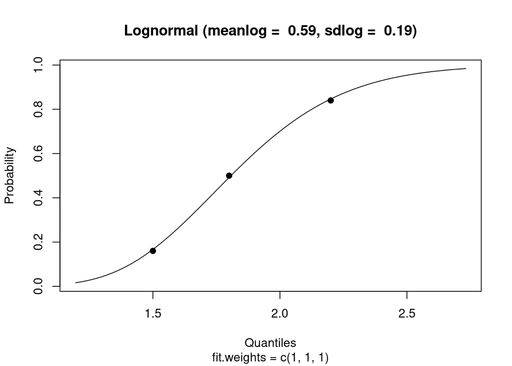

```
## The fitting procedure 'L-BFGS-B' was successful!
```

```
## $par
## [1] 0.5171894 0.3200099
##
## $value
## [1] 0.0001466232
##
## $counts
## function gradient
##       12       12
##
## $convergence
## [1] 0
##
## $message
## [1] "CONVERGENCE: REL_REDUCTION_OF_F <= FACTR*EPSMCH"
```

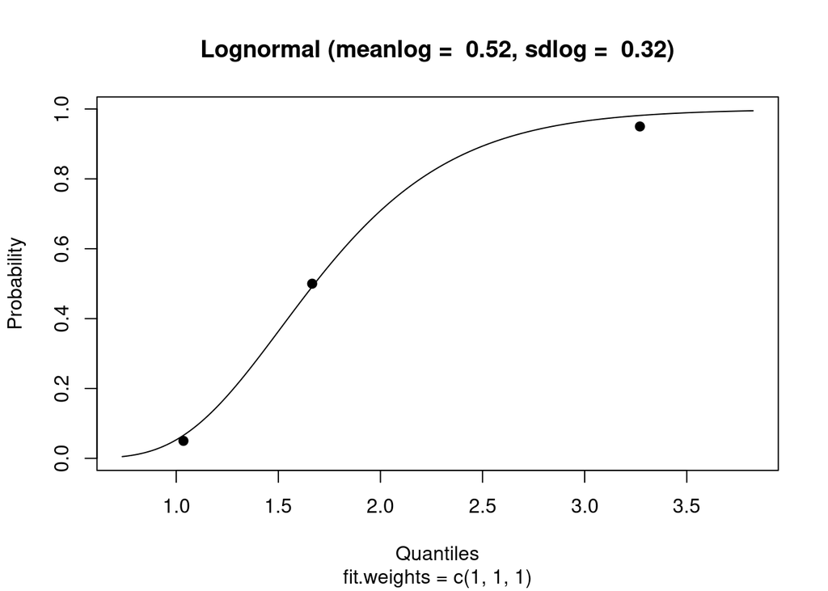

```
## The fitting procedure 'L-BFGS-B' was successful!
```

```
## $par
## [1] 0.5333458 0.2088702
##
## $value
## [1] 4.883697e-05
##
## $counts
## function gradient
##       13       13
##
## $convergence
## [1] 0
##
## $message
## [1] "CONVERGENCE: REL_REDUCTION_OF_F <= FACTR*EPSMCH"
```

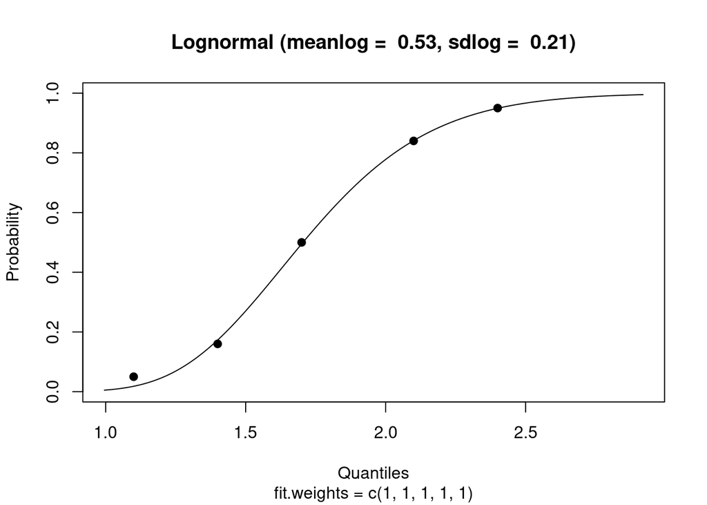

```
## The fitting procedure 'L-BFGS-B' was successful!
```

```
## $par
## [1] 0.5011289 0.2300069
##
## $value
## [1] 0.0001314229
##
## $counts
## function gradient
##       13       13
##
## $convergence
## [1] 0
##
## $message
## [1] "CONVERGENCE: REL_REDUCTION_OF_F <= FACTR*EPSMCH"
```

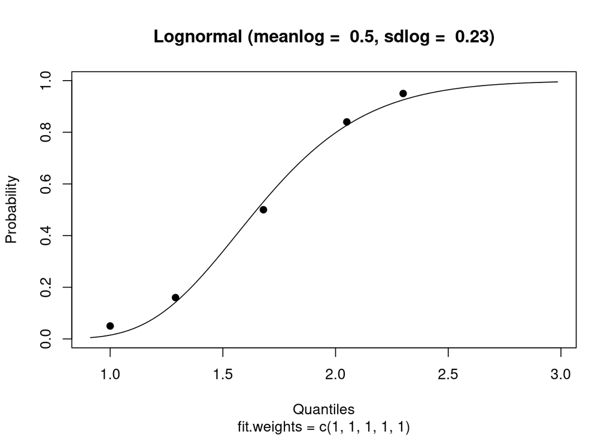

```
## The fitting procedure 'L-BFGS-B' was successful!
```

```
## $par
## [1] 0.5279935 0.1582696
##
## $value
## [1] 0.0002056946
##
## $counts
## function gradient
##       13       13
##
## $convergence
## [1] 0
##
## $message
## [1] "CONVERGENCE: REL_REDUCTION_OF_F <= FACTR*EPSMCH"
```

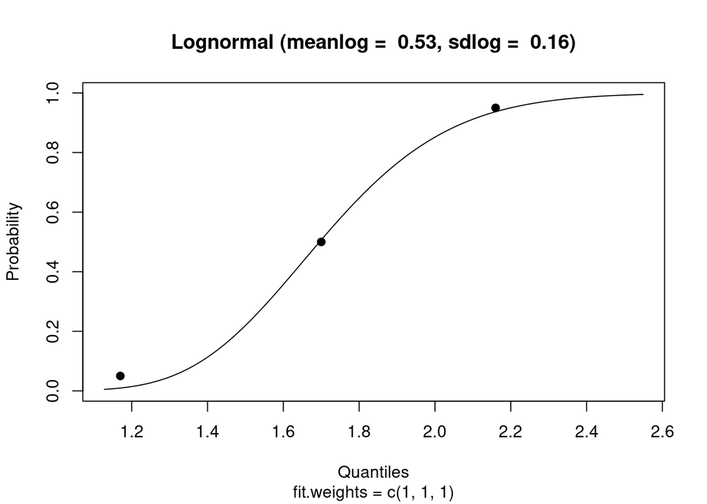

```
## The fitting procedure 'L-BFGS-B' was successful!
```

```
## $par
## [1] 0.4561703 0.2572126
##
## $value
## [1] 0.0001190927
##
## $counts
## function gradient
##       13       13
##
## $convergence
## [1] 0
##
## $message
## [1] "CONVERGENCE: REL_REDUCTION_OF_F <= FACTR*EPSMCH"
```

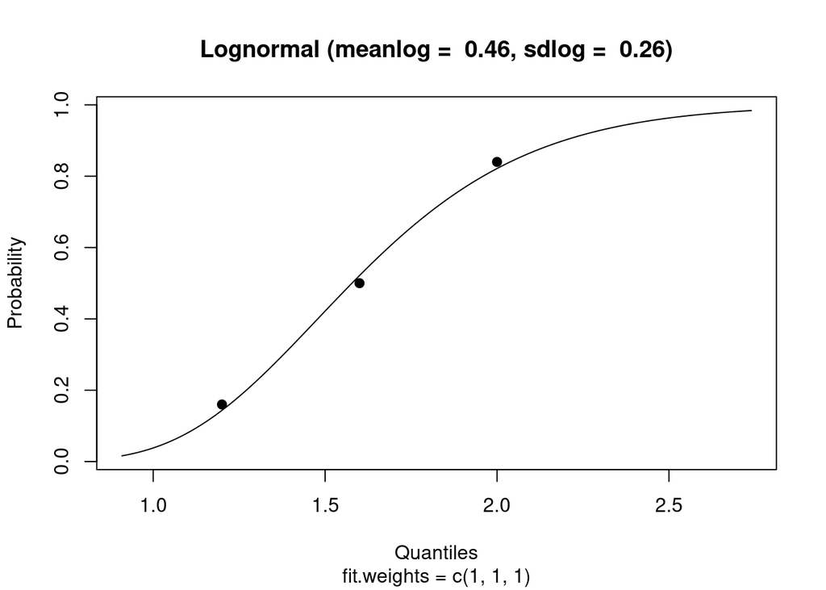

## Plot all of the lognormal fits

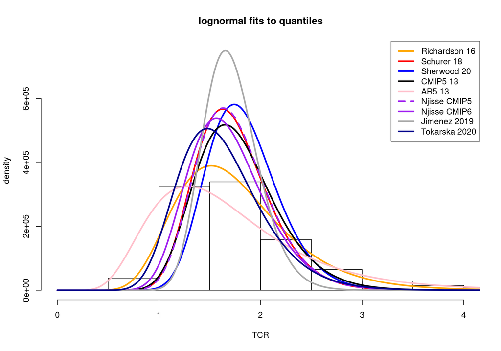

## How close are the lognormal fits?

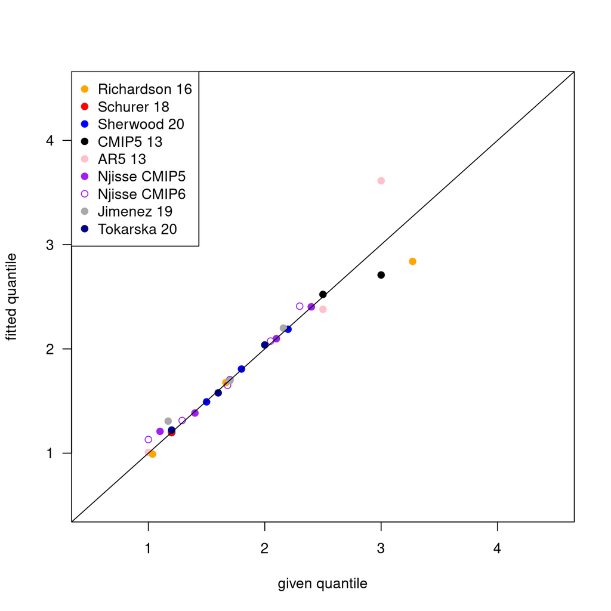

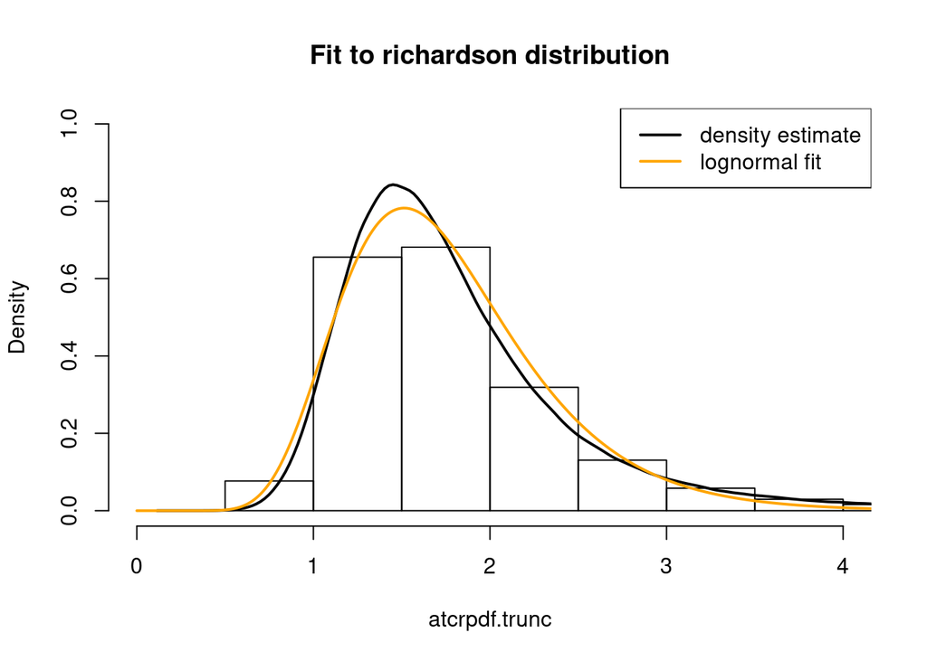

```
## The fitting procedure 'L-BFGS-B' was successful!
## The fitting procedure 'L-BFGS-B' was successful!
```

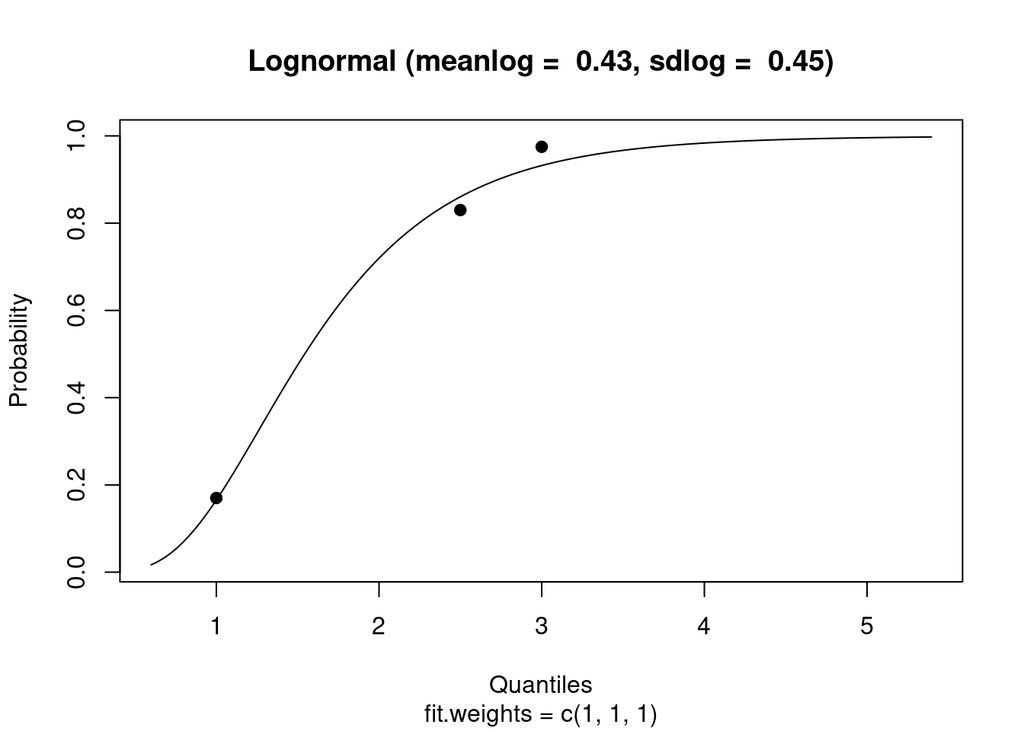

```
## The fitting procedure 'L-BFGS-B' was successful!
```

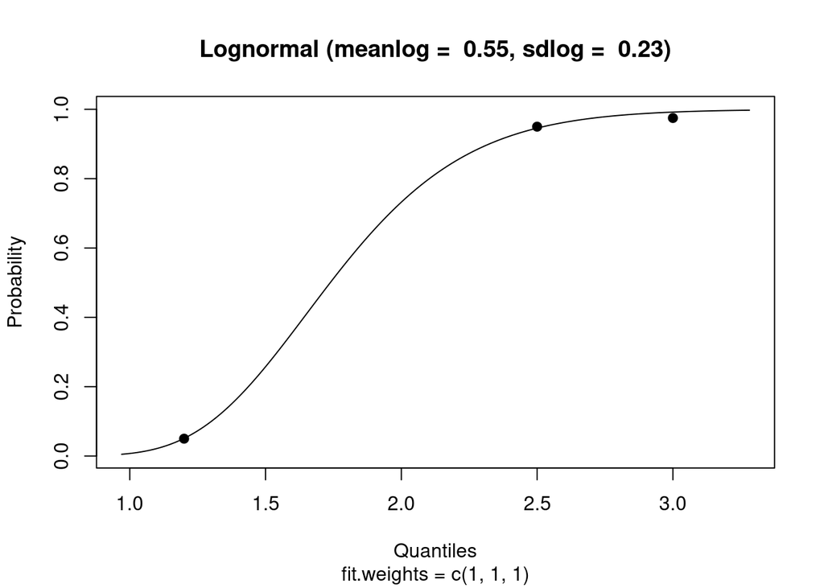

```
## The fitting procedure 'L-BFGS-B' was successful!
```

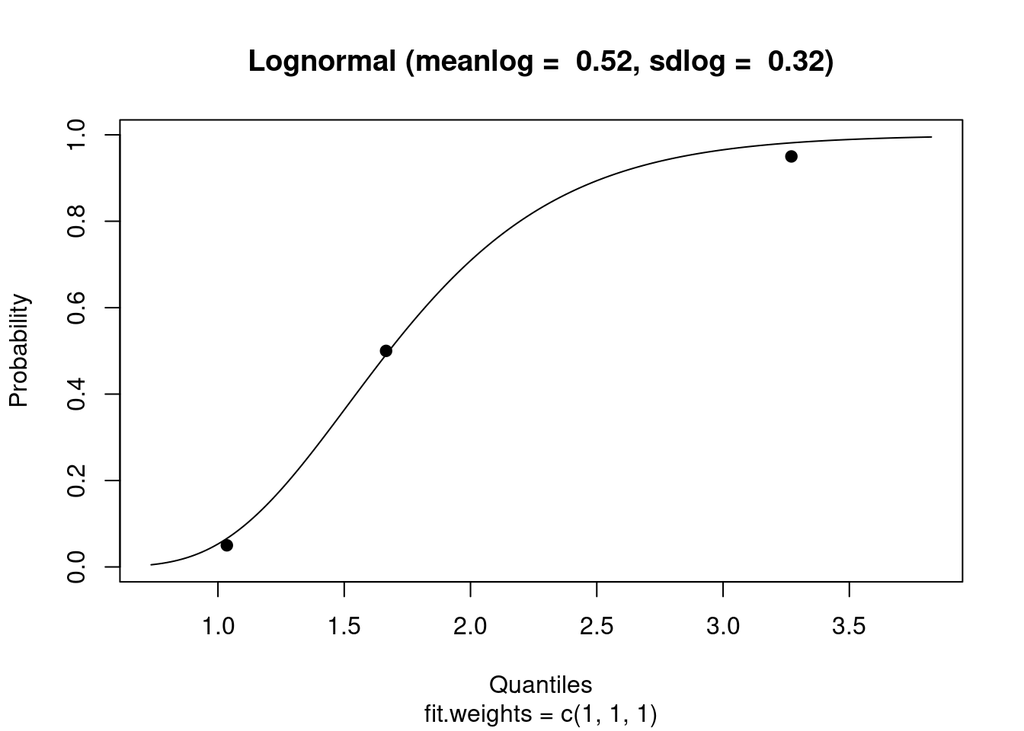

```
## The fitting procedure 'L-BFGS-B' was successful!
```

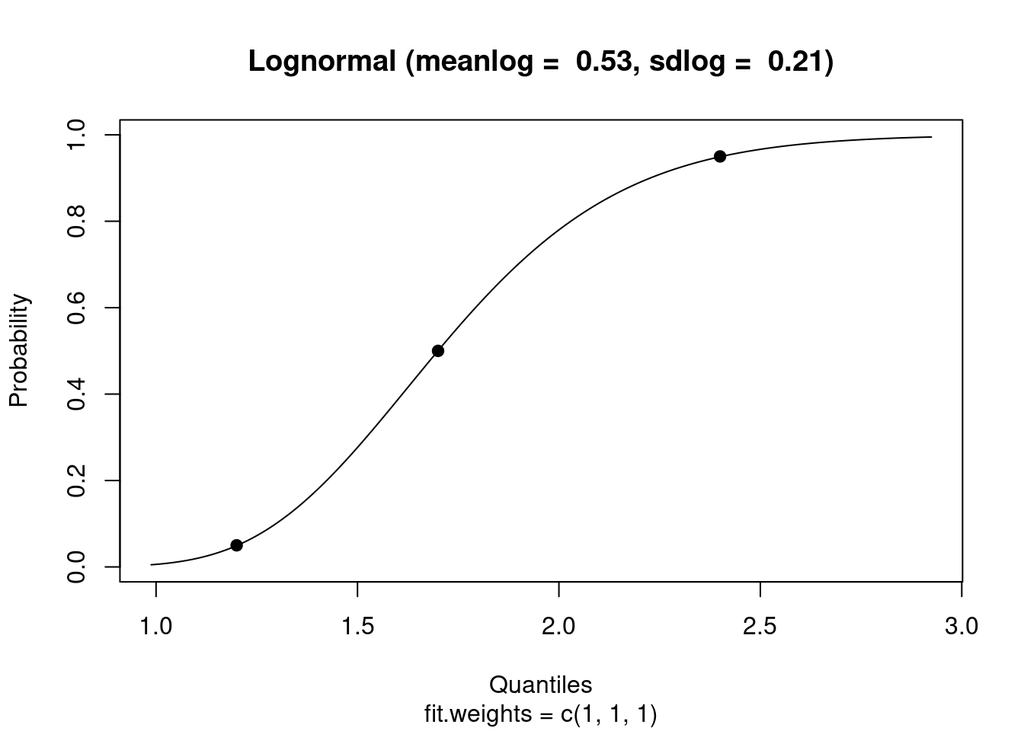

```
## The fitting procedure 'L-BFGS-B' was successful!
```

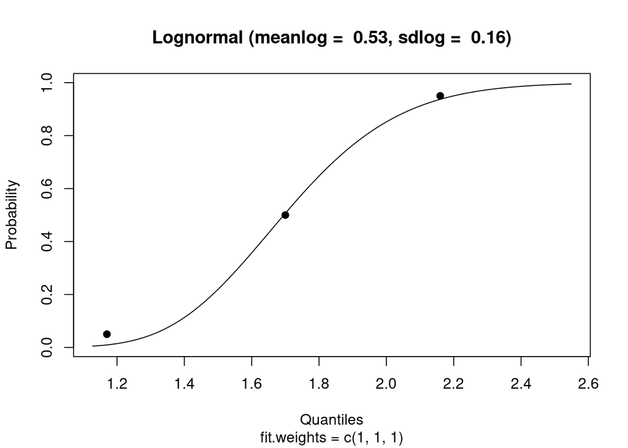

```
## The fitting procedure 'L-BFGS-B' was successful!
```

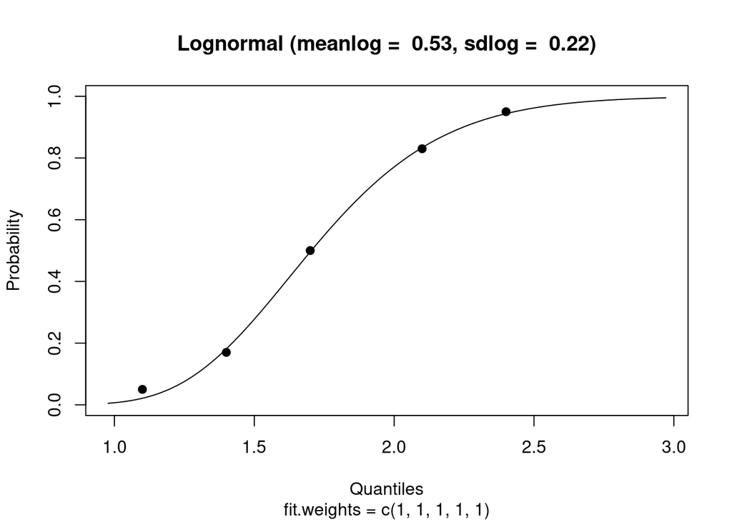

```
## The fitting procedure 'L-BFGS-B' was successful!
```

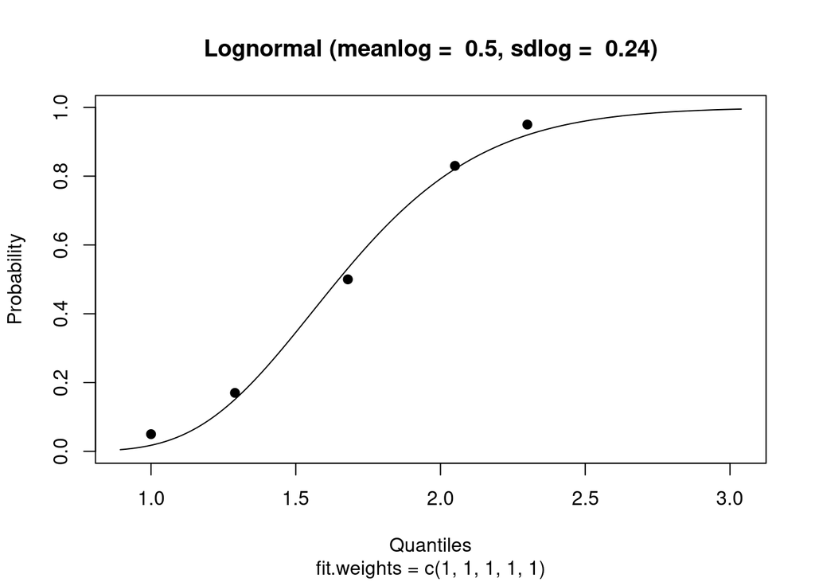

```
## The fitting procedure 'L-BFGS-B' was successful!
```

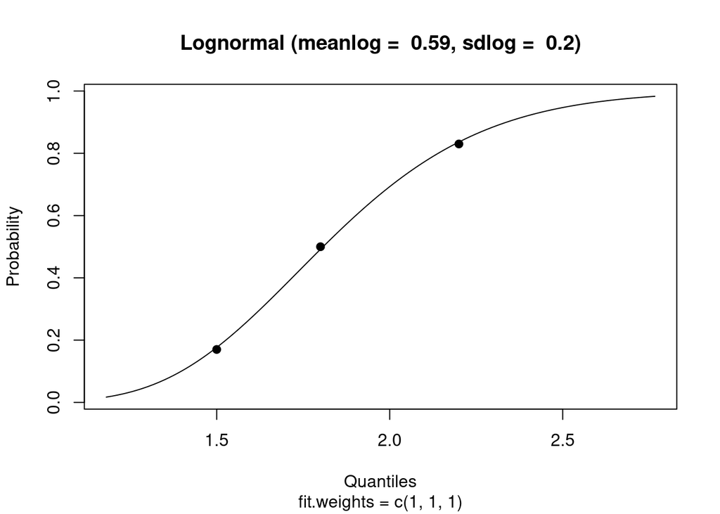

```
## The fitting procedure 'L-BFGS-B' was successful!
```

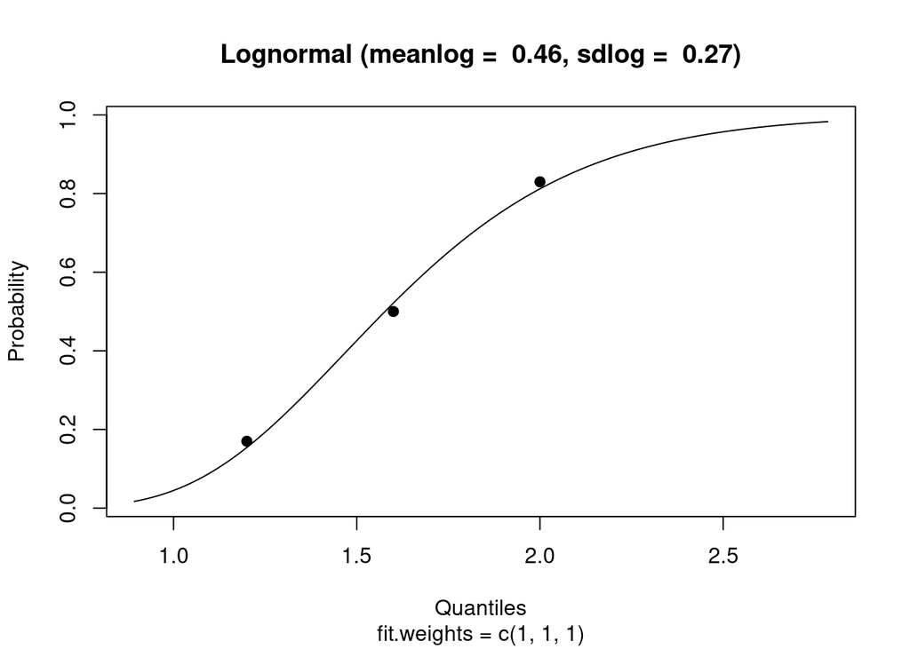

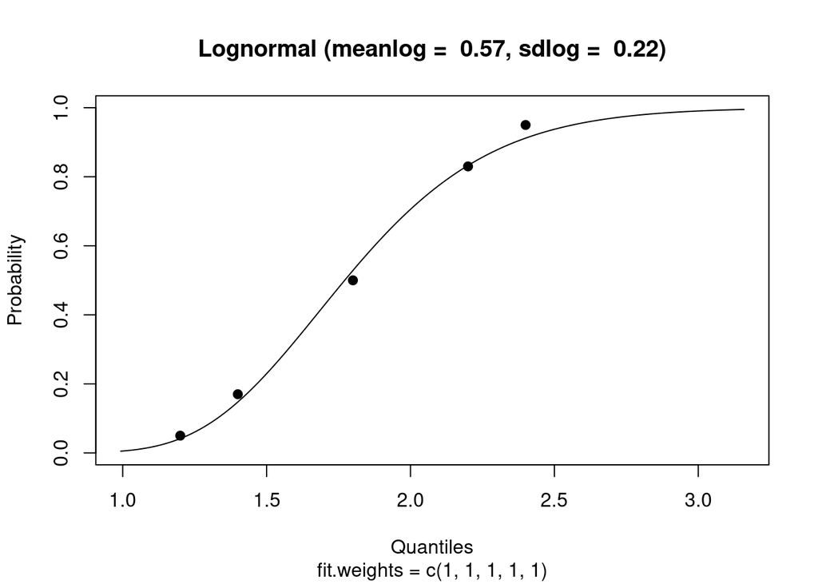

## TCR in the AR6

Caption https://www.ipcc.ch/report/ar6/wg1/figures/chapter-7/figure-7-18

Big version (in the report) https://www.ipcc.ch/report/ar6/wg1/downloads/figures/IPCC_AR6_WGI_Figure_7_18.png

Somebody has calculated the CMIP6 TCR values! (this could be useful)

# Plot TCR fitted lognormal distributions

Blue dots are CMIP6 model TCR measured and published in the AR6

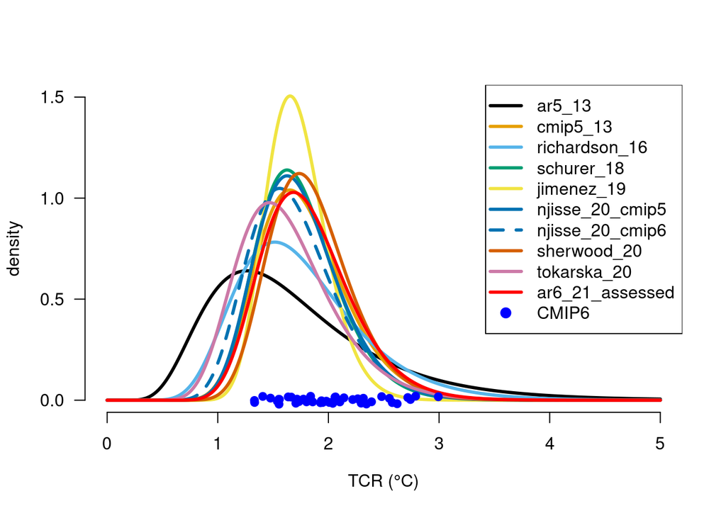

# Plot projected CO2 at warming levels

Transfer function

## Sample from the lognormal distributions and push through the TCR transfer function

Truncated TCR values below 0.5, as you get odd things happening.

Also project CMIP6 TCR into CO2 concentration at GWLs by pushing the AR6-published TCR values through the transfer function.

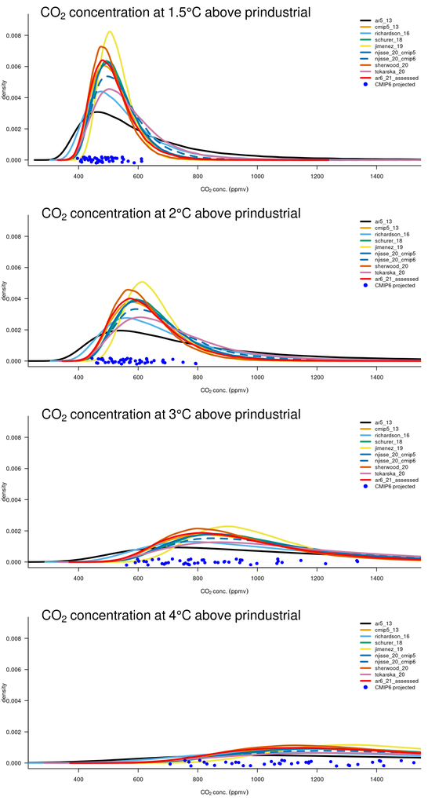

## Load CMIP6 models actual CO2 at 1.5 and 2 degrees at SSPs

This section plots the CO2 measured at warming levels 1.5, 2, 3 & 4 degrees in CMIP6 models against the CO2 levels you would expect from projecting their measured TCR through the transfer function.

Measured CO2 levels are consistently below what you would expect from their TCR.

SSP585

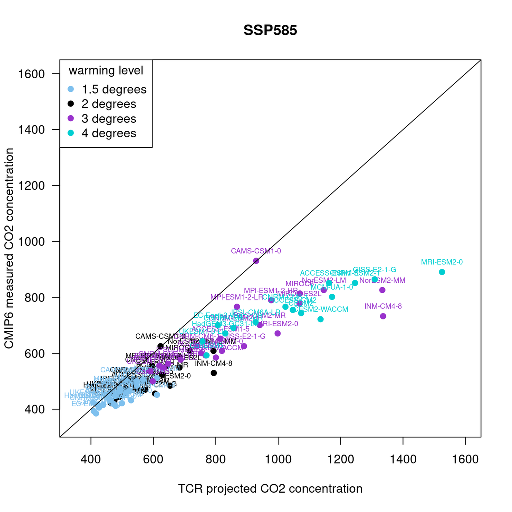

SSP370

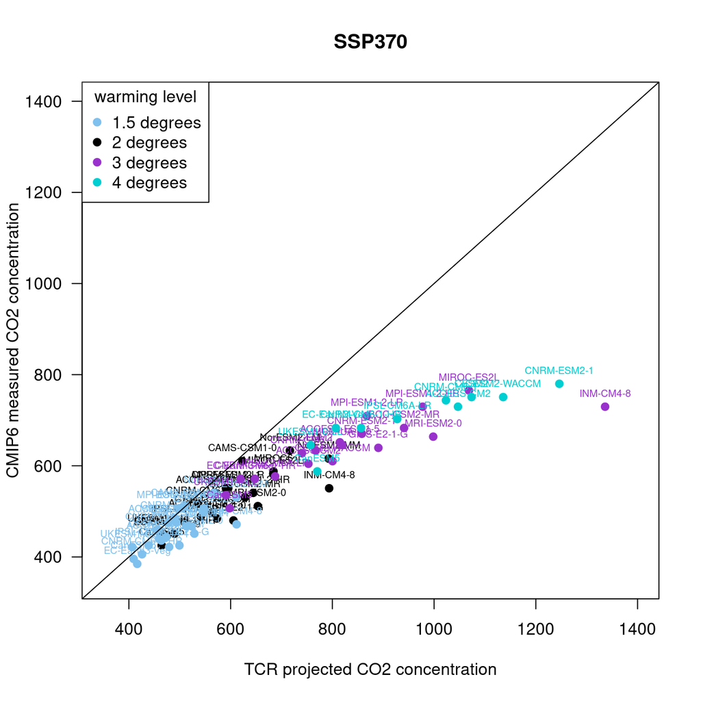

SSP245

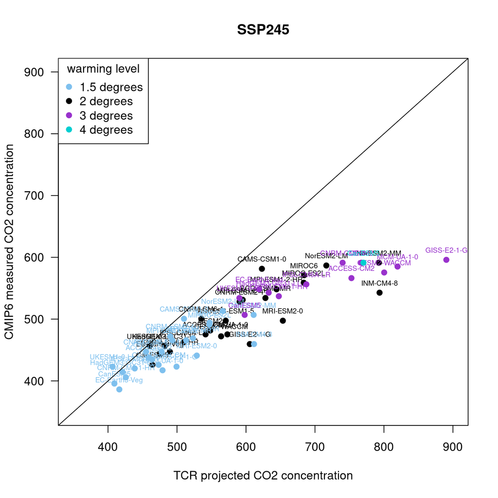